# Project: Investigate a Dataset - [No show appointments Data Analysis]

- Introduction
- Data Wrangling
- Exploratory Data Analysis
- Conclusions

## Introduction

In this project , I will be analyzing data assoicated with information from 100k medical appointments in Brazil and is focused in if the patients show up for their appointment or not.we have a number of characteristics about the patients are included in each rows. we also have a number of columns[PatientId,AppointmentID,Gender,ScheduledDay,AppointmentDay,Age,Neighbourhood,Scholarship,Hipertension,Diabetes,Alcoholism,Handcap,SMS_received,No-show].

### Dataset Description

we have a csv file called noshowappointments-kagglev2-may-2016.csv have information about 100k medical appointments in brazil.

### Question(s) for Analysis

what are the important factors that will help us and the less imortant factors that should remove from our data before start visualize our data?

```python
# Use this cell to set up import statements for all of the packages that you
#   plan to use.
import numpy as np
import pandas as pd
import matplotlib.pyplot as plt
import seaborn as sns
% matplotlib inline

# Remember to include a 'magic word' so that your visualizations are plotted
#   inline with the notebook. See this page for more:
#   http://ipython.readthedocs.io/en/stable/interactive/magics.html
```

```python
# Upgrade pandas to use dataframe.explode() function.
!pip install --upgrade pandas==0.25.0
```

[output not shown]

## Data Wrangling

In this section of the report, you will load in the data, check for cleanliness, and then trim and clean your dataset for analysis.

### General Properties

```python
# Load your data and print out a few lines. Perform operations to inspect data
#   types and look for instances of missing or possibly errant data.
import pandas as pd
df = pd.read_csv('noshowappointments-kagglev2-may-2016.csv')
df.head()
```

|  | PatientId | AppointmentID | Gender | ScheduledDay | AppointmentDay | Age | Neighbourhood | Scholarship | Hipertension | Diabetes | Alcoholism | Handcap | SMS_received | No-show |
| --- | --- | --- | --- | --- | --- | --- | --- | --- | --- | --- | --- | --- | --- | --- |
| 0 | 2.987250e+13 | 5642903 | F | 2016-04-29T18:38:08Z | 2016-04-29T00:00:00Z | 62 | JARDIM DA PENHA | 0 | 1 | 0 | 0 | 0 | 0 | No |
| 1 | 5.589978e+14 | 5642503 | M | 2016-04-29T16:08:27Z | 2016-04-29T00:00:00Z | 56 | JARDIM DA PENHA | 0 | 0 | 0 | 0 | 0 | 0 | No |
| 2 | 4.262962e+12 | 5642549 | F | 2016-04-29T16:19:04Z | 2016-04-29T00:00:00Z | 62 | MATA DA PRAIA | 0 | 0 | 0 | 0 | 0 | 0 | No |
| 3 | 8.679512e+11 | 5642828 | F | 2016-04-29T17:29:31Z | 2016-04-29T00:00:00Z | 8 | PONTAL DE CAMBURI | 0 | 0 | 0 | 0 | 0 | 0 | No |
| 4 | 8.841186e+12 | 5642494 | F | 2016-04-29T16:07:23Z | 2016-04-29T00:00:00Z | 56 | JARDIM DA PENHA | 0 | 1 | 1 | 0 | 0 | 0 | No |

```python
# data information
df.info()
```

```
<class 'pandas.core.frame.DataFrame'>
RangeIndex: 110527 entries, 0 to 110526
Data columns (total 14 columns):
PatientId         110527 non-null float64
AppointmentID     110527 non-null int64
Gender            110527 non-null object
ScheduledDay      110527 non-null object
AppointmentDay    110527 non-null object
Age               110527 non-null int64
Neighbourhood     110527 non-null object
Scholarship       110527 non-null int64
Hipertension      110527 non-null int64
Diabetes          110527 non-null int64
Alcoholism        110527 non-null int64
Handcap           110527 non-null int64
SMS_received      110527 non-null int64
No-show           110527 non-null object
dtypes: float64(1), int64(8), object(5)
memory usage: 11.8+ MB
```

from our data formation i found the scheduledday and appointmentday columns are object data types but in fact they are datetime type so we should comvert them .

```python
# data shape
df.shape
```

```
(110527, 14)
```

our data consists of 110527 rows and 14 columns

```python
# check if there are any missing value in the data
df.isnull().sum()
```

```
PatientId         0
AppointmentID     0
Gender            0
ScheduledDay      0
AppointmentDay    0
Age               0
Neighbourhood     0
Scholarship       0
Hipertension      0
Diabetes          0
Alcoholism        0
Handcap           0
SMS_received      0
No-show           0
dtype: int64
```

there are no missing values in our data

```python
# checking duplicated rows
df.duplicated().sum()
```

```
0
```

there is no dupllication in rows

```python
#convert date columns in string to datetime type
df.AppointmentDay = pd.to_datetime(df.AppointmentDay)
df.ScheduledDay = pd.to_datetime(df.ScheduledDay)
df.head()
```

|  | PatientId | AppointmentID | Gender | ScheduledDay | AppointmentDay | Age | Neighbourhood | Scholarship | Hipertension | Diabetes | Alcoholism | Handcap | SMS_received | No-show |
| --- | --- | --- | --- | --- | --- | --- | --- | --- | --- | --- | --- | --- | --- | --- |
| 0 | 2.987250e+13 | 5642903 | F | 2016-04-29 18:38:08 | 2016-04-29 | 62 | JARDIM DA PENHA | 0 | 1 | 0 | 0 | 0 | 0 | No |
| 1 | 5.589978e+14 | 5642503 | M | 2016-04-29 16:08:27 | 2016-04-29 | 56 | JARDIM DA PENHA | 0 | 0 | 0 | 0 | 0 | 0 | No |
| 2 | 4.262962e+12 | 5642549 | F | 2016-04-29 16:19:04 | 2016-04-29 | 62 | MATA DA PRAIA | 0 | 0 | 0 | 0 | 0 | 0 | No |
| 3 | 8.679512e+11 | 5642828 | F | 2016-04-29 17:29:31 | 2016-04-29 | 8 | PONTAL DE CAMBURI | 0 | 0 | 0 | 0 | 0 | 0 | No |
| 4 | 8.841186e+12 | 5642494 | F | 2016-04-29 16:07:23 | 2016-04-29 | 56 | JARDIM DA PENHA | 0 | 1 | 1 | 0 | 0 | 0 | No |

I converted these two columns to datetime type instead of object type because they represent the date when patients record for attendence

```python
df.info()
```

```
<class 'pandas.core.frame.DataFrame'>
RangeIndex: 110527 entries, 0 to 110526
Data columns (total 14 columns):
PatientId         110527 non-null float64
AppointmentID     110527 non-null int64
Gender            110527 non-null object
ScheduledDay      110527 non-null datetime64[ns]
AppointmentDay    110527 non-null datetime64[ns]
Age               110527 non-null int64
Neighbourhood     110527 non-null object
Scholarship       110527 non-null int64
Hipertension      110527 non-null int64
Diabetes          110527 non-null int64
Alcoholism        110527 non-null int64
Handcap           110527 non-null int64
SMS_received      110527 non-null int64
No-show           110527 non-null object
dtypes: datetime64[ns](2), float64(1), int64(8), object(3)
memory usage: 11.8+ MB
```

here our info after convert two columns to datetime instead of object

```python
# getting some statistic information about our data
df.describe()
```

|  | PatientId | AppointmentID | Age | Scholarship | Hipertension | Diabetes | Alcoholism | Handcap | SMS_received |
| --- | --- | --- | --- | --- | --- | --- | --- | --- | --- |
| count | 1.105270e+05 | 1.105270e+05 | 110527.000000 | 110527.000000 | 110527.000000 | 110527.000000 | 110527.000000 | 110527.000000 | 110527.000000 |
| mean | 1.474963e+14 | 5.675305e+06 | 37.088874 | 0.098266 | 0.197246 | 0.071865 | 0.030400 | 0.022248 | 0.321026 |
| std | 2.560949e+14 | 7.129575e+04 | 23.110205 | 0.297675 | 0.397921 | 0.258265 | 0.171686 | 0.161543 | 0.466873 |
| min | 3.921784e+04 | 5.030230e+06 | -1.000000 | 0.000000 | 0.000000 | 0.000000 | 0.000000 | 0.000000 | 0.000000 |
| 25% | 4.172614e+12 | 5.640286e+06 | 18.000000 | 0.000000 | 0.000000 | 0.000000 | 0.000000 | 0.000000 | 0.000000 |
| 50% | 3.173184e+13 | 5.680573e+06 | 37.000000 | 0.000000 | 0.000000 | 0.000000 | 0.000000 | 0.000000 | 0.000000 |
| 75% | 9.439172e+13 | 5.725524e+06 | 55.000000 | 0.000000 | 0.000000 | 0.000000 | 0.000000 | 0.000000 | 1.000000 |
| max | 9.999816e+14 | 5.790484e+06 | 115.000000 | 1.000000 | 1.000000 | 1.000000 | 1.000000 | 4.000000 | 1.000000 |

I made this to show the max and min and check if there are any mistakes with our data. from this, the age column has a mistake value the min value is -1 and that impossible so we should remove this value

```python
#filter our data
# there are some columns don't help us during our  analysis so, we can delete them.
df.drop(['PatientId','AppointmentID','ScheduledDay'], axis=1, inplace = True)
df.head()
```

|  | Gender | AppointmentDay | Age | Neighbourhood | Scholarship | Hipertension | Diabetes | Alcoholism | Handcap | SMS_received | No-show |
| --- | --- | --- | --- | --- | --- | --- | --- | --- | --- | --- | --- |
| 0 | F | 2016-04-29 | 62 | JARDIM DA PENHA | 0 | 1 | 0 | 0 | 0 | 0 | No |
| 1 | M | 2016-04-29 | 56 | JARDIM DA PENHA | 0 | 0 | 0 | 0 | 0 | 0 | No |
| 2 | F | 2016-04-29 | 62 | MATA DA PRAIA | 0 | 0 | 0 | 0 | 0 | 0 | No |
| 3 | F | 2016-04-29 | 8 | PONTAL DE CAMBURI | 0 | 0 | 0 | 0 | 0 | 0 | No |
| 4 | F | 2016-04-29 | 56 | JARDIM DA PENHA | 0 | 1 | 1 | 0 | 0 | 0 | No |

i removed these columns beacuse i saw they didn't help me in our data analysis

```python
# in the age column there are some unexpected values
#so we should remove these values
df.Age.unique()
np.sort(df.Age.unique())
```

```
array([ -1,   0,   1,   2,   3,   4,   5,   6,   7,   8,   9,  10,  11,
        12,  13,  14,  15,  16,  17,  18,  19,  20,  21,  22,  23,  24,
        25,  26,  27,  28,  29,  30,  31,  32,  33,  34,  35,  36,  37,
        38,  39,  40,  41,  42,  43,  44,  45,  46,  47,  48,  49,  50,
        51,  52,  53,  54,  55,  56,  57,  58,  59,  60,  61,  62,  63,
        64,  65,  66,  67,  68,  69,  70,  71,  72,  73,  74,  75,  76,
        77,  78,  79,  80,  81,  82,  83,  84,  85,  86,  87,  88,  89,
        90,  91,  92,  93,  94,  95,  96,  97,  98,  99, 100, 102, 115])
```

I knew from staticts analysis there are mistakes values with age colmn so i made this to show its components

```python
# number of messages sent to patients but here we have a problem
df.SMS_received.unique()
```

```
array([0, 1])
```

i made this to check our data before cleaning

```python
# Handcap columns describe if the patient has handicap but here we have a problem
#the vaule should be equal to true or false
df.Handcap.unique()
```

```
array([0, 1, 2, 3, 4])
```

i made this to check our data before cleaning

we should change the name of the sms received columns to the handcap and the same with the handcap colums but we should rename handcap to handicap

### Data Cleaning

in this section we will clean our data but we shoild noted that our data has no missing values and no duplicated rows

```python
# number of messages sent to patients but here we have a problem
#rename the sms_received column
df= df.rename(columns={'SMS_received' : 'Handicap'})
df.head()
```

|  | Gender | AppointmentDay | Age | Neighbourhood | Scholarship | Hipertension | Diabetes | Alcoholism | Handcap | Handicap | No-show |
| --- | --- | --- | --- | --- | --- | --- | --- | --- | --- | --- | --- |
| 0 | F | 2016-04-29 | 62 | JARDIM DA PENHA | 0 | 1 | 0 | 0 | 0 | 0 | No |
| 1 | M | 2016-04-29 | 56 | JARDIM DA PENHA | 0 | 0 | 0 | 0 | 0 | 0 | No |
| 2 | F | 2016-04-29 | 62 | MATA DA PRAIA | 0 | 0 | 0 | 0 | 0 | 0 | No |
| 3 | F | 2016-04-29 | 8 | PONTAL DE CAMBURI | 0 | 0 | 0 | 0 | 0 | 0 | No |
| 4 | F | 2016-04-29 | 56 | JARDIM DA PENHA | 0 | 1 | 1 | 0 | 0 | 0 | No |

```python
# Handcap columns describe if the patient has handicap but here we have a problem
#the vaule should be equal to true or false
# rename the handcap column
df= df.rename(columns={'Handcap' : 'SMS_received' })
df.head()
```

|  | Gender | AppointmentDay | Age | Neighbourhood | Scholarship | Hipertension | Diabetes | Alcoholism | SMS_received | Handicap | No-show |
| --- | --- | --- | --- | --- | --- | --- | --- | --- | --- | --- | --- |
| 0 | F | 2016-04-29 | 62 | JARDIM DA PENHA | 0 | 1 | 0 | 0 | 0 | 0 | No |
| 1 | M | 2016-04-29 | 56 | JARDIM DA PENHA | 0 | 0 | 0 | 0 | 0 | 0 | No |
| 2 | F | 2016-04-29 | 62 | MATA DA PRAIA | 0 | 0 | 0 | 0 | 0 | 0 | No |
| 3 | F | 2016-04-29 | 8 | PONTAL DE CAMBURI | 0 | 0 | 0 | 0 | 0 | 0 | No |
| 4 | F | 2016-04-29 | 56 | JARDIM DA PENHA | 0 | 1 | 1 | 0 | 0 | 0 | No |

this our data aftet the replace the names of the two columns by each other

```python
df.SMS_received.value_counts()
```

```
0    108286
1      2042
2       183
3        13
4         3
Name: SMS_received, dtype: int64
```

```python
# correct the age column by choose the value that greater than 0
df= df[df.Age>=0]
```

made this to remove unexpected values

```python
df.Age.unique()
np.sort(df.Age.unique())
```

```
array([  0,   1,   2,   3,   4,   5,   6,   7,   8,   9,  10,  11,  12,
        13,  14,  15,  16,  17,  18,  19,  20,  21,  22,  23,  24,  25,
        26,  27,  28,  29,  30,  31,  32,  33,  34,  35,  36,  37,  38,
        39,  40,  41,  42,  43,  44,  45,  46,  47,  48,  49,  50,  51,
        52,  53,  54,  55,  56,  57,  58,  59,  60,  61,  62,  63,  64,
        65,  66,  67,  68,  69,  70,  71,  72,  73,  74,  75,  76,  77,
        78,  79,  80,  81,  82,  83,  84,  85,  86,  87,  88,  89,  90,
        91,  92,  93,  94,  95,  96,  97,  98,  99, 100, 102, 115])
```

check the age column to show their value after removing unexpected value

```python
# rename the No-show column to No_show
df.rename(columns={'No-show':'No_show'}, inplace = True)
df.head(1)
```

|  | Gender | AppointmentDay | Age | Neighbourhood | Scholarship | Hipertension | Diabetes | Alcoholism | SMS_received | Handicap | No_show |
| --- | --- | --- | --- | --- | --- | --- | --- | --- | --- | --- | --- |
| 0 | F | 2016-04-29 | 62 | JARDIM DA PENHA | 0 | 1 | 0 | 0 | 0 | 0 | No |

## Exploratory Data Analysis

Now that you've trimmed and cleaned your data, you're ready to move on to exploration. **Compute statistics** and **create visualizations** with the goal of addressing the research questions that you posed in the Introduction section.

### General look

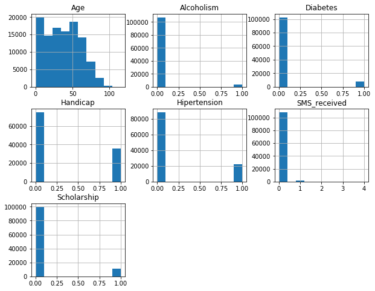

```python
df.hist(figsize=(10,8));
```

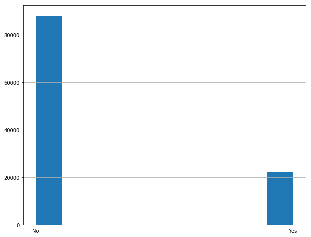

```python
df['No_show'].hist(figsize=(10,8));
```

the number of patients who attend is greater than the number who didn't attend

```python
#  exploring our data but first i will divide the No_show column totwo groups (show and noshow )
show = df.No_show== 'No'
noshow = df.No_show== 'Yes'
df[show].count() , df[noshow].count()
```

```
(Gender            88207
 AppointmentDay    88207
 Age               88207
 Neighbourhood     88207
 Scholarship       88207
 Hipertension      88207
 Diabetes          88207
 Alcoholism        88207
 SMS_received      88207
 Handicap          88207
 No_show           88207
 dtype: int64, Gender            22319
 AppointmentDay    22319
 Age               22319
 Neighbourhood     22319
 Scholarship       22319
 Hipertension      22319
 Diabetes          22319
 Alcoholism        22319
 SMS_received      22319
 Handicap          22319
 No_show           22319
 dtype: int64)
```

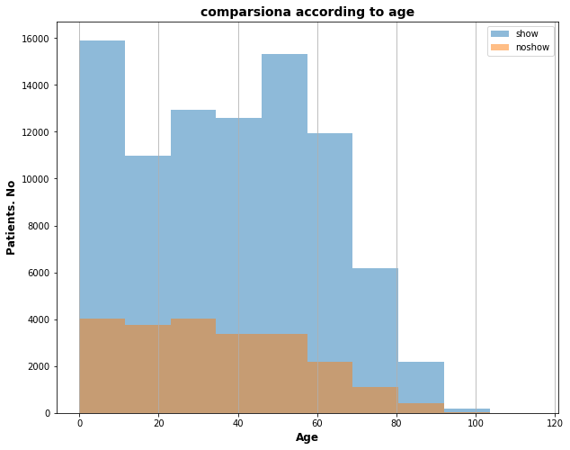

```python
# does age affected by the show and no show patients
plt.figure(figsize =(10,8))
df.Age[show].hist(alpha =0.5,label = 'show')
df.Age[noshow].hist(alpha =0.5,label = 'noshow')
plt.legend();
plt.title('comparsiona according to age', fontsize = 14, weight = "bold")
plt.xlabel('Age', fontsize =12, weight = "bold")
plt.ylabel('Patients. No', fontsize = 12, weight='bold')
plt.grid(axis='y')
```

from this histogram we can see that the people have ages from 0 to 8 is the largest percentage of people who attend in their appointments ,followed by the ages of people range from approximately 45 to 58, followed by the ages from 25 to 35 and the lowest percentage of ages is from 90 to over a hundred. for people who do not attend, we see that from 0 to 8 and 25 to 35 ages have the same percentage and the largest percentag of people who do not attend and te lowest percentage is foe people whose ages range from ninety to over a hundred and this reflect the interest in health ranges from the ages of 0 to 8 followed by the ages from 45 to 58 and the least interest of the elderly.

### investigation the relation between patients who attend and not attend with other factors.

```python
def myGroPlot(df, grpVar, yVar=None, title=None, ylabel=None, rotation=None, figsize=(14,6), alpha=0.7):
    '''base function for groupby plotting of dependent variables to no_show column'''
    # plotting
    df[show].groupby([grpVar])[yVar].mean().plot.bar(edgecolor='black', figsize=figsize, rot=0, width=0.6, color='blue', alpha=alpha, label='show')
    df[noshow].groupby([grpVar])[yVar].mean().plot.bar(edgecolor='black', figsize=figsize, rot=0, width=0.6, color='red', alpha=alpha,label ='noshow')
    plt.title(f' {title}'.title(), fontsize = 14, weight = "bold")
    plt.xlabel(grpVar.title(), fontsize =8, weight = "bold")
    plt.ylabel(f'{ylabel}'.title(), fontsize = 8, weight='bold')
    plt.xticks(rotation=rotation)
    plt.grid(axis='y')
    plt.legend();
```

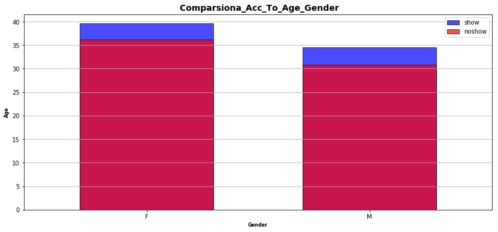

```python
myGroPlot(df, 'Gender', yVar='Age', title='comparsiona_acc_to_age_gender', ylabel='Age', rotation=None, figsize=(14,6), alpha=0.7)
```

i think there are no correlation between age and gender and the relation between them don't affect on the attendence

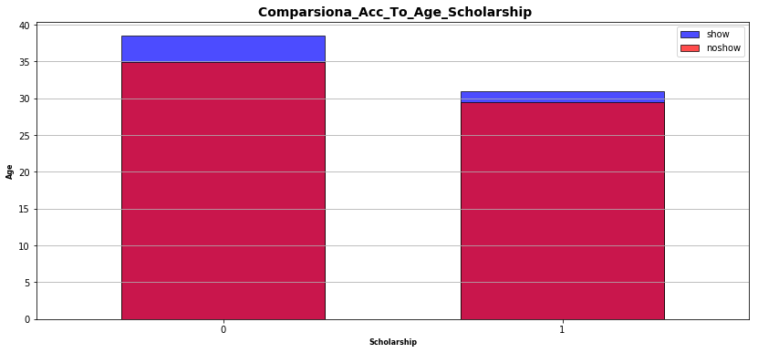

```python
myGroPlot(df, 'Scholarship', yVar='Age', title='comparsiona_acc_to_age_Scholarship', ylabel='Age', rotation=None, figsize=(14,6), alpha=0.7)
```

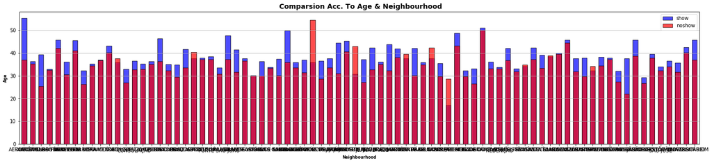

```python
myGroPlot(df, 'Neighbourhood', yVar='Age', title='comparsion acc. to Age & Neighbourhood', ylabel='Age', rotation=None, figsize=(25,5), alpha=0.7)
```

from this plot we can say that there are some neighbourhood that patients don't attend to them at all we should check why people don't attend and the patients attendence differ according to their ages but almost ages rangs between 20 to 40. the most neighbourhood with high ages is AEROPORTO.

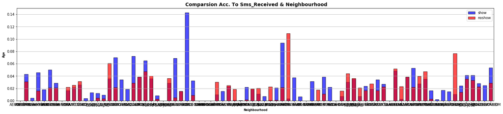

```python
myGroPlot(df, 'Neighbourhood', yVar='SMS_received', title='comparsion acc. to SMS_received & Neighbourhood', ylabel='Age', rotation=None, figsize=(25,5), alpha=0.7)
```

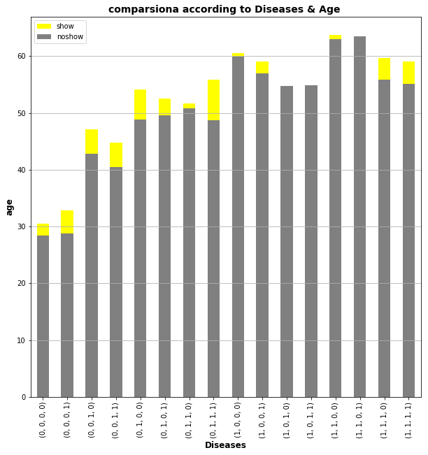

```python
# does age and diseases affect the people who attend and not attend
plt.figure(figsize=(10,10))
diseases =['Hipertension','Diabetes', 'Alcoholism','Handicap']
df[show].groupby(diseases).mean()['Age'].plot(kind ='bar', color ='yellow', label = 'show')
df[noshow].groupby(['Hipertension','Diabetes', 'Alcoholism','Handicap']).mean()['Age'].plot(kind ='bar', color ='grey', label = 'noshow')
plt.legend()
plt.title('comparsiona according to Diseases & Age ', fontsize = 14, weight = "bold")
plt.xlabel( 'Diseases',fontsize = 12, weight='bold')
plt.ylabel('age',fontsize = 12, weight='bold')
plt.grid(axis='y');
```

```python
df[show].groupby(['Hipertension','Diabetes', 'Alcoholism','Handicap']).mean()['Age'], df[noshow].groupby(['Hipertension','Diabetes', 'Alcoholism','Handicap']).mean()['Age']
```

```
(Hipertension  Diabetes  Alcoholism  Handicap
 0             0         0           0           30.453227
                                     1           32.882803
                         1           0           47.171545
                                     1           44.794788
               1         0           0           54.177861
                                     1           52.551495
                         1           0           51.686275
                                     1           55.833333
 1             0         0           0           60.560298
                                     1           59.062999
                         1           0           54.190616
                                     1           54.811518
               1         0           0           63.720779
                                     1           63.165393
```

[output cut: 20 more lines]

```python
df.Handicap.value_counts()
```

```
0    75044
1    35482
Name: Handicap, dtype: int64
```

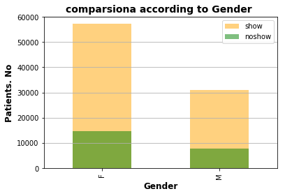

```python
df.Gender[show].value_counts().plot(kind='bar', alpha = 0.5, color = 'orange', label='show')
df.Gender[noshow].value_counts().plot(kind='bar', alpha = 0.5, color = 'green', label='noshow')
plt.legend();
plt.title('comparsiona according to Gender ', fontsize = 14, weight = "bold")
plt.xlabel('Gender', fontsize =12, weight = "bold")
plt.ylabel('Patients. No', fontsize = 12, weight='bold')
plt.grid(axis='y')
```

```python
df.Gender[show].value_counts(),df.Gender[noshow].value_counts()
```

```
(F    57245
 M    30962
 Name: Gender, dtype: int64, F    14594
 M     7725
 Name: Gender, dtype: int64)
```

from this we see that the number of women who attend and didn't attend is greater than the number of man in both sataes. and this mean there are many women have diseases than men

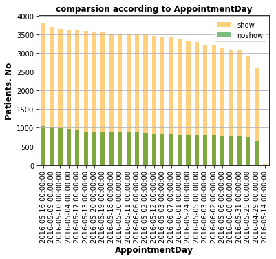

```python
df.AppointmentDay[show].value_counts().plot(kind='bar', alpha = 0.5, color = 'orange', label='show')
df.AppointmentDay[noshow].value_counts().plot(kind='bar', alpha = 0.5, color = 'green', label='noshow')
plt.legend();
plt.title('comparsion according to AppointmentDay',fontsize =12, weight = "bold")
plt.xlabel('AppointmentDay', fontsize =12, weight = "bold")
plt.ylabel('Patients. No', fontsize = 12, weight='bold')
plt.grid(axis='y')
```

the largest number of patients attend on 16/5 while the smallest attend on 14/5 i think yhis affected by the neighbourhood.

```python
# Investigating neighbourhoods exlusively in regards to show or no shows
hoods_noshow = df[noshow].groupby(['Neighbourhood']).count()['No_show']
hoods = df.groupby(['Neighbourhood']).count()['No_show']
hoods_show = df[show].groupby(['Neighbourhood']).count()['No_show']

percentages_noshow = hoods_noshow/hoods*100
percentages_noshow.sort_values()
```

```
Neighbourhood
ILHA DO BOI                      8.571429
AEROPORTO                       12.500000
MÁRIO CYPRESTE                  14.555256
SOLON BORGES                    14.712154
DE LOURDES                      15.409836
DO CABRAL                       15.714286
SANTA MARTHA                    15.841584
JARDIM DA PENHA                 16.275471
DO QUADRO                       16.489988
VILA RUBIM                      16.568743
MORADA DE CAMBURI               16.666667
MATA DA PRAIA                   17.080745
REPÚBLICA                       17.125749
CONSOLAÇÃO                      17.223837
PONTAL DE CAMBURI               17.391304
SANTO ANTÔNIO                   17.625637
REDENÇÃO                        17.707663
NOVA PALESTINA                  17.756184
JABOUR                          17.975289
SANTA LUÍZA                     17.990654
COMDUSA                         18.064516
JOANA D´ARC                     18.079888
TABUAZEIRO                      18.295019
FORTE SÃO JOÃO                  18.316570
PRAIA DO CANTO                  18.357488
ANTÔNIO HONÓRIO                 18.450185
BOA VISTA                       18.589744
FRADINHOS                       18.604651
CONQUISTA                       18.845701
JARDIM CAMBURI                  18.984061
                                  ...
MARIA ORTIZ                     20.999139
SÃO PEDRO                       21.037582
UNIVERSITÁRIO                   21.052632
CENTRO                          21.085783
ROMÃO                           21.409214
NAZARETH                        21.481481
BARRO VERMELHO                  21.513002
SÃO JOSÉ                        21.648963
```

[output cut: 8 more lines]

```
BENTO FERREIRA                  22.494172
GURIGICA                        22.596630
PRAIA DO SUÁ                    22.826087
ANDORINHAS                      23.032714
CARATOÍRA                       23.040936
ILHA DO PRÍNCIPE                23.477493
HORTO                           24.000000
JESUS DE NAZARETH               24.395373
ITARARÉ                         26.266363
SANTA CLARA                     26.482213
SANTA CECÍLIA                   27.455357
SANTOS DUMONT                   28.918495
ILHAS OCEÂNICAS DE TRINDADE    100.000000
PARQUE INDUSTRIAL                     NaN
Name: No_show, Length: 81, dtype: float64
```

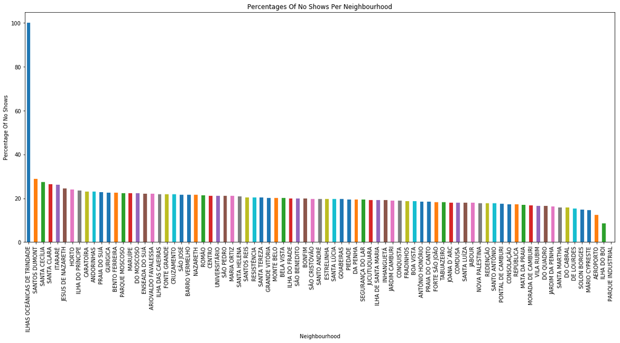

```python
# Plotting percentages of no_shows per neighbourhood
percentages_noshow.sort_values(ascending=False).plot(kind='bar', title='Percentages of No shows per Neighbourhood'.title(), figsize=(20,8));
plt.ylabel('Percentage of no_shows'.title().replace("_"," "))
plt.xlabel('neighbourhood'.title());
```

FROM THIS PLOT we can see the largest percentage of people who didin't attend is in ILHAS OCEANICAS DE TRINDADE around(100%) and patients from PARQUE INDUSTRIAL didn't absent but the largest percentage of patients who attend in above 90% is in PARQUE INDUSTRIAL

## conclusion

-Number of femal who showing and not showing is greater than the number of male.

```python
from subprocess import call
call(['python', '-m', 'nbconvert', 'Investigate_a_Dataset.ipynb'])
```

```
0
```